# Supervised Learning Project MSCS 5622

## Project by Sean Norman | April 2025

### Executive Summary

**Data Source Reference**:

- U.S. Bureau of Labor Statistics. (2025). *Consumer Price Index for All Urban Consumers (CPI-U): U.S. city average, All series [CUUR0000+]*. Retrieved from https://data.bls.gov/dataViewer/view/timeseries/CUUR0000SA0
- Federal Reserve Bank of St. Louis. (2025). *Consumer Credit Outstanding (Levels), Revolving [REVOLNS]*. Retrieved from https://fred.stlouisfed.org/series/REVOLNS

### Report Summary

Comments are included in all code cells to explain the thought process and intent of what the code is doing.

At the end of this notebook is a report summary that addresses the approach along with discussion around learnings, takeaways, suggestions, and future considerations for next steps. Please review these details to better understand the conclusion of this exercise.

### Learning & Algorithms Utilized

In this analysis the following modeling was performed:

- Linear Regression
- Random Forest
- Random Forest w/ Hyperparameter Tuning
- XGBoost (Gradient Boost)
- XGBoost (Gradient Boost) w/ Hyperparameter Tuning

## Technical notes

This notebook relies on a specific set of Python packages. To ensure reproducibility, it is highly recommended to use the virtual environment setup files.

- **Environment Management:** A Python virtual environment is used to manage dependencies.
- **Dependencies:** All required packages and their versions are listed in the `requirements.txt` file.
- **Setup Instructions:** For detailed steps on how to create and activate the virtual environment using the provided scripts (`setup.sh` for macOS/Linux, `setup.bat` for Windows), please refer to the environment-config.md file in the project root directory.

Following the setup instructions will ensure you have the correct environment to run this notebook successfully.

## Import Libraries

Import the necessary libraries for data manipulation, analysis, visualization, and machine learning.

```python
import pandas as pd
import numpy as np
import matplotlib.pyplot as plt
import seaborn as sns
import statsmodels.api as sm
import statsmodels.formula.api as smf
import os
import pandas_datareader.data as web

from xgboost import XGBRegressor
from statsmodels.stats.outliers_influence import variance_inflation_factor

# Scikit-learn for modeling
from sklearn.model_selection import train_test_split, TimeSeriesSplit, GridSearchCV, RandomizedSearchCV
from sklearn.linear_model import LogisticRegression
from sklearn.ensemble import RandomForestRegressor
from sklearn.tree import DecisionTreeClassifier
from sklearn.svm import SVC
from sklearn.neighbors import KNeighborsClassifier
from sklearn.linear_model import LinearRegression
from sklearn.metrics import classification_report, confusion_matrix, accuracy_score, mean_squared_error, r2_score

# IPython for displaying outputs
from IPython.display import display

# Optional: Ignore warnings
import warnings
warnings.filterwarnings('ignore')

print("Libraries imported successfully.")
```

```
Libraries imported successfully.
```

```python
# set data directory to load from
data_loc = 'data/'
```

### Load and clean the CPI Data

The CPI Data contains extra rows as it is an XLSX file in addition to additional columns that refer to different half durations of a given annum. To best utilize the data we will need to transpose the data eventually so that the date can be an index and the features are the respective columns.

```python
# Load the dataset for CPI Data with series xlsx
cpi_data = pd.read_excel(os.path.join(data_loc, 'cpi-with-series2019.xlsx'), sheet_name='BLS Data Series')
# Display the first few rows of the dataset
display(cpi_data.head())
```

|  | Consumer Price Index for All Urban Consumers (CPI-U) | Unnamed: 1 | Unnamed: 2 | Unnamed: 3 | Unnamed: 4 | Unnamed: 5 | Unnamed: 6 | Unnamed: 7 | Unnamed: 8 | Unnamed: 9 | ... | Unnamed: 89 | Unnamed: 90 | Unnamed: 91 | Unnamed: 92 | Unnamed: 93 | Unnamed: 94 | Unnamed: 95 | Unnamed: 96 | Unnamed: 97 | Unnamed: 98 |
| --- | --- | --- | --- | --- | --- | --- | --- | --- | --- | --- | --- | --- | --- | --- | --- | --- | --- | --- | --- | --- | --- |
| 0 | Years: | 2019 to 2025 | NaN | NaN | NaN | NaN | NaN | NaN | NaN | NaN | ... | NaN | NaN | NaN | NaN | NaN | NaN | NaN | NaN | NaN | NaN |
| 1 | NaN | NaN | NaN | NaN | NaN | NaN | NaN | NaN | NaN | NaN | ... | NaN | NaN | NaN | NaN | NaN | NaN | NaN | NaN | NaN | NaN |
| 2 | Series ID | Jan\n2019 | Feb\n2019 | Mar\n2019 | Apr\n2019 | May\n2019 | Jun\n2019 | Jul\n2019 | Aug\n2019 | Sep\n2019 | ... | May\n2025 | Jun\n2025 | Jul\n2025 | Aug\n2025 | Sep\n2025 | Oct\n2025 | Nov\n2025 | Dec\n2025 | HALF1\n2025 | HALF2\n2025 |
| 3 | CUUR0000SA0E | 200.563 | 202.74 | 211.724 | 222.499 | 225.773 | 221.373 | 222.492 | 216.978 | 215.418 | ... | NaN | NaN | NaN | NaN | NaN | NaN | NaN | NaN | NaN | NaN |
| 4 | CUUR0000SA0L1 | 250.974 | 252.077 | 253.643 | 255.194 | 255.759 | 255.825 | 256.286 | 256.25 | 256.401 | ... | NaN | NaN | NaN | NaN | NaN | NaN | NaN | NaN | NaN | NaN |

5 rows × 99 columns

CPI Data was in XLSX format so we need to clean up the structure of the dataframe:

- remove the first two rows
- transpose so features are columns

```python
# Remove the first two rows of the DataFrame
cpi_data = cpi_data.iloc[2:]
# Reset the index of the DataFrame
cpi_data.reset_index(drop=True, inplace=True)

# Transpose the DataFrame
cpi_data = cpi_data.T

# Set the first row as the column names
cpi_data.columns = cpi_data.iloc[0]

# Remove the first row from the DataFrame
cpi_data = cpi_data[1:]
# Reset the index of the DataFrame
cpi_data.reset_index(drop=True, inplace=True)

# Display the first few rows of the modified DataFrame
display(cpi_data.head())
```

| Consumer Price Index for All Urban Consumers (CPI-U) | Series ID | CUUR0000SA0E | CUUR0000SA0L1 | CUUR0000SA0L12 | CUUR0000SA0L12E | CUUR0000SA0L12E4 | CUUR0000SA0L1E | CUUR0000SA0L2 | CUUR0000SA0L5 | CUUR0000SA0LE | ... | CUUR0000SS62053 | CUUR0000SS62054 | CUUR0000SS62055 | CUUR0000SS68021 | CUUR0000SS68023 | CUUR0000SSEA011 | CUUR0000SSEE041 | CUUR0000SSFV031A | CUUR0000SSGE013 | CUUR0000SSHJ031 |
| --- | --- | --- | --- | --- | --- | --- | --- | --- | --- | --- | --- | --- | --- | --- | --- | --- | --- | --- | --- | --- | --- |
| 0 | Jan\n2019 | 200.563 | 250.974 | 224.129 | 230.902 | 236.57 | 260.122 | 230.765 | 240.27 | 258.855 | ... | 195.373 | 260.653 | 129.37 | 172.297 | 256.585 | 236.214 | NaN | 148.889 | 71.391 | NaN |
| 1 | Feb\n2019 | 202.74 | 252.077 | 225.199 | 231.788 | 237.48 | 261.114 | 231.792 | 241.335 | 259.817 | ... | 196.02 | 263.218 | 129.457 | 172.297 | 262.951 | 238.122 | NaN | 148.726 | 70.643 | NaN |
| 2 | Mar\n2019 | 211.724 | 253.643 | 226.909 | 232.222 | 237.836 | 261.836 | 233.29 | 242.776 | 260.505 | ... | 194.408 | 264.507 | 132.573 | 172.297 | 244.686 | 238.055 | NaN | 148.74 | 70.127 | NaN |
| 3 | Apr\n2019 | 222.499 | 255.194 | 228.655 | 232.38 | 238.012 | 262.332 | 234.723 | 244.134 | 260.925 | ... | 194.783 | 265.119 | 134.836 | 172.297 | 245.159 | 238.826 | NaN | 148.747 | 70.785 | NaN |
| 4 | May\n2019 | 225.773 | 255.759 | 229.061 | 232.28 | 238.051 | 262.59 | 235.131 | 244.629 | 261.203 | ... | 194.787 | 266.297 | 133.271 | 172.297 | 254.104 | 237.06 | NaN | 148.747 | 71.53 | 104.685 |

5 rows × 398 columns

Update the name of the first column for the months and drop the rows containing "HALFS"

```python
# Update the name of the first column to 'Date'
cpi_data.rename(columns={cpi_data.columns[0]: 'Date'}, inplace=True)
# Display the first few rows of the modified DataFrame

# Update values of the Date column to remove the \n character
cpi_data['Date'] = cpi_data['Date'].str.replace('\n', ' ')
# Display the first few rows of the modified DataFrame
display(cpi_data.head())
```

| Consumer Price Index for All Urban Consumers (CPI-U) | Date | CUUR0000SA0E | CUUR0000SA0L1 | CUUR0000SA0L12 | CUUR0000SA0L12E | CUUR0000SA0L12E4 | CUUR0000SA0L1E | CUUR0000SA0L2 | CUUR0000SA0L5 | CUUR0000SA0LE | ... | CUUR0000SS62053 | CUUR0000SS62054 | CUUR0000SS62055 | CUUR0000SS68021 | CUUR0000SS68023 | CUUR0000SSEA011 | CUUR0000SSEE041 | CUUR0000SSFV031A | CUUR0000SSGE013 | CUUR0000SSHJ031 |
| --- | --- | --- | --- | --- | --- | --- | --- | --- | --- | --- | --- | --- | --- | --- | --- | --- | --- | --- | --- | --- | --- |
| 0 | Jan 2019 | 200.563 | 250.974 | 224.129 | 230.902 | 236.57 | 260.122 | 230.765 | 240.27 | 258.855 | ... | 195.373 | 260.653 | 129.37 | 172.297 | 256.585 | 236.214 | NaN | 148.889 | 71.391 | NaN |
| 1 | Feb 2019 | 202.74 | 252.077 | 225.199 | 231.788 | 237.48 | 261.114 | 231.792 | 241.335 | 259.817 | ... | 196.02 | 263.218 | 129.457 | 172.297 | 262.951 | 238.122 | NaN | 148.726 | 70.643 | NaN |
| 2 | Mar 2019 | 211.724 | 253.643 | 226.909 | 232.222 | 237.836 | 261.836 | 233.29 | 242.776 | 260.505 | ... | 194.408 | 264.507 | 132.573 | 172.297 | 244.686 | 238.055 | NaN | 148.74 | 70.127 | NaN |
| 3 | Apr 2019 | 222.499 | 255.194 | 228.655 | 232.38 | 238.012 | 262.332 | 234.723 | 244.134 | 260.925 | ... | 194.783 | 265.119 | 134.836 | 172.297 | 245.159 | 238.826 | NaN | 148.747 | 70.785 | NaN |
| 4 | May 2019 | 225.773 | 255.759 | 229.061 | 232.28 | 238.051 | 262.59 | 235.131 | 244.629 | 261.203 | ... | 194.787 | 266.297 | 133.271 | 172.297 | 254.104 | 237.06 | NaN | 148.747 | 71.53 | 104.685 |

5 rows × 398 columns

Update the dtypes for all the features

```python
# Update the dtype of all columns after Date to float
cpi_data.iloc[:, 1:] = cpi_data.iloc[:, 1:].astype(float)
# Display the first few rows of the modified DataFrame

# Drop the rows where Date contains 'Half'
cpi_data = cpi_data[~cpi_data['Date'].str.contains('HALF', na=False)]

# Update the dtype of the Date column to datetime
cpi_data['Date'] = pd.to_datetime(cpi_data['Date'], format='%b %Y')

display(cpi_data.info())
```

```
<class 'pandas.core.frame.DataFrame'>
Index: 84 entries, 0 to 95
Columns: 398 entries, Date to CUUR0000SSHJ031
dtypes: datetime64[ns](1), object(397)
memory usage: 261.8+ KB
```

```
None
```

```python
# Remove the rows from the dataframe after 2025-02-01 to match our REVOLNS dataset date range
cpi_data = cpi_data[cpi_data['Date'] <= '2025-02-01']

# print all values of the Date column
print(cpi_data['Date'].unique())
```

```
<DatetimeArray>
['2019-01-01 00:00:00', '2019-02-01 00:00:00', '2019-03-01 00:00:00',
 '2019-04-01 00:00:00', '2019-05-01 00:00:00', '2019-06-01 00:00:00',
 '2019-07-01 00:00:00', '2019-08-01 00:00:00', '2019-09-01 00:00:00',
 '2019-10-01 00:00:00', '2019-11-01 00:00:00', '2019-12-01 00:00:00',
 '2020-01-01 00:00:00', '2020-02-01 00:00:00', '2020-03-01 00:00:00',
 '2020-04-01 00:00:00', '2020-05-01 00:00:00', '2020-06-01 00:00:00',
 '2020-07-01 00:00:00', '2020-08-01 00:00:00', '2020-09-01 00:00:00',
 '2020-10-01 00:00:00', '2020-11-01 00:00:00', '2020-12-01 00:00:00',
 '2021-01-01 00:00:00', '2021-02-01 00:00:00', '2021-03-01 00:00:00',
 '2021-04-01 00:00:00', '2021-05-01 00:00:00', '2021-06-01 00:00:00',
 '2021-07-01 00:00:00', '2021-08-01 00:00:00', '2021-09-01 00:00:00',
 '2021-10-01 00:00:00', '2021-11-01 00:00:00', '2021-12-01 00:00:00',
 '2022-01-01 00:00:00', '2022-02-01 00:00:00', '2022-03-01 00:00:00',
 '2022-04-01 00:00:00', '2022-05-01 00:00:00', '2022-06-01 00:00:00',
 '2022-07-01 00:00:00', '2022-08-01 00:00:00', '2022-09-01 00:00:00',
 '2022-10-01 00:00:00', '2022-11-01 00:00:00', '2022-12-01 00:00:00',
 '2023-01-01 00:00:00', '2023-02-01 00:00:00', '2023-03-01 00:00:00',
 '2023-04-01 00:00:00', '2023-05-01 00:00:00', '2023-06-01 00:00:00',
 '2023-07-01 00:00:00', '2023-08-01 00:00:00', '2023-09-01 00:00:00',
 '2023-10-01 00:00:00', '2023-11-01 00:00:00', '2023-12-01 00:00:00',
 '2024-01-01 00:00:00', '2024-02-01 00:00:00', '2024-03-01 00:00:00',
 '2024-04-01 00:00:00', '2024-05-01 00:00:00', '2024-06-01 00:00:00',
 '2024-07-01 00:00:00', '2024-08-01 00:00:00', '2024-09-01 00:00:00',
 '2024-10-01 00:00:00', '2024-11-01 00:00:00', '2024-12-01 00:00:00',
 '2025-01-01 00:00:00', '2025-02-01 00:00:00']
Length: 74, dtype: datetime64[ns]
```

### Load and clean the FRED Data

```python
# Load the FRED data from the REVOLNS csv file
revolns_data = pd.read_csv(os.path.join(data_loc, 'REVOLNS2019.csv'))
# Display the first few rows of the dataset
display(revolns_data.head())
```

|  | observation_date | REVOLNS |
| --- | --- | --- |
| 0 | 2019-01-01 | 1032945.77 |
| 1 | 2019-02-01 | 1014636.99 |
| 2 | 2019-03-01 | 1005252.17 |
| 3 | 2019-04-01 | 1013742.65 |
| 4 | 2019-05-01 | 1028795.53 |

```python
# Update date column name to 'DATE'
revolns_data.rename(columns={revolns_data.columns[0]: 'DATE'}, inplace=True)
# Modify the Date column to datetime format
revolns_data['DATE'] = pd.to_datetime(revolns_data['DATE'], format='%Y-%m-%d')
# Display the first few rows of the modified DataFrame
display(revolns_data.head())
display(revolns_data.info())
```

|  | DATE | REVOLNS |
| --- | --- | --- |
| 0 | 2019-01-01 | 1032945.77 |
| 1 | 2019-02-01 | 1014636.99 |
| 2 | 2019-03-01 | 1005252.17 |
| 3 | 2019-04-01 | 1013742.65 |
| 4 | 2019-05-01 | 1028795.53 |

```
<class 'pandas.core.frame.DataFrame'>
RangeIndex: 74 entries, 0 to 73
Data columns (total 2 columns):
 #   Column   Non-Null Count  Dtype
---  ------   --------------  -----
 0   DATE     74 non-null     datetime64[ns]
 1   REVOLNS  74 non-null     float64
dtypes: datetime64[ns](1), float64(1)
memory usage: 1.3 KB
```

```
None
```

```python
print("Values of date column in revolns_data:")
# print all values of the Date column
print(revolns_data['DATE'].unique())
```

```
Values of date column in revolns_data:
<DatetimeArray>
['2019-01-01 00:00:00', '2019-02-01 00:00:00', '2019-03-01 00:00:00',
 '2019-04-01 00:00:00', '2019-05-01 00:00:00', '2019-06-01 00:00:00',
 '2019-07-01 00:00:00', '2019-08-01 00:00:00', '2019-09-01 00:00:00',
 '2019-10-01 00:00:00', '2019-11-01 00:00:00', '2019-12-01 00:00:00',
 '2020-01-01 00:00:00', '2020-02-01 00:00:00', '2020-03-01 00:00:00',
 '2020-04-01 00:00:00', '2020-05-01 00:00:00', '2020-06-01 00:00:00',
 '2020-07-01 00:00:00', '2020-08-01 00:00:00', '2020-09-01 00:00:00',
 '2020-10-01 00:00:00', '2020-11-01 00:00:00', '2020-12-01 00:00:00',
 '2021-01-01 00:00:00', '2021-02-01 00:00:00', '2021-03-01 00:00:00',
 '2021-04-01 00:00:00', '2021-05-01 00:00:00', '2021-06-01 00:00:00',
 '2021-07-01 00:00:00', '2021-08-01 00:00:00', '2021-09-01 00:00:00',
 '2021-10-01 00:00:00', '2021-11-01 00:00:00', '2021-12-01 00:00:00',
 '2022-01-01 00:00:00', '2022-02-01 00:00:00', '2022-03-01 00:00:00',
 '2022-04-01 00:00:00', '2022-05-01 00:00:00', '2022-06-01 00:00:00',
 '2022-07-01 00:00:00', '2022-08-01 00:00:00', '2022-09-01 00:00:00',
 '2022-10-01 00:00:00', '2022-11-01 00:00:00', '2022-12-01 00:00:00',
 '2023-01-01 00:00:00', '2023-02-01 00:00:00', '2023-03-01 00:00:00',
 '2023-04-01 00:00:00', '2023-05-01 00:00:00', '2023-06-01 00:00:00',
 '2023-07-01 00:00:00', '2023-08-01 00:00:00', '2023-09-01 00:00:00',
 '2023-10-01 00:00:00', '2023-11-01 00:00:00', '2023-12-01 00:00:00',
 '2024-01-01 00:00:00', '2024-02-01 00:00:00', '2024-03-01 00:00:00',
 '2024-04-01 00:00:00', '2024-05-01 00:00:00', '2024-06-01 00:00:00',
 '2024-07-01 00:00:00', '2024-08-01 00:00:00', '2024-09-01 00:00:00',
 '2024-10-01 00:00:00', '2024-11-01 00:00:00', '2024-12-01 00:00:00',
 '2025-01-01 00:00:00', '2025-02-01 00:00:00']
Length: 74, dtype: datetime64[ns]
```

### Merge REVOLNS with CPI Data

```python
# Merge the two datasets on the Date column
# Merge cpi_data with the relevant columns from revolns_data
# Use an inner join to keep only dates present in both dataframes
# Specify left_on='Date' and right_on='DATE' for the join keys
cpi_revolns = pd.merge(cpi_data, revolns_data[['DATE', 'REVOLNS']], left_on='Date', right_on='DATE', how='inner')

# Drop the redundant 'DATE' column that came from revolns_data
cpi_revolns = cpi_revolns.drop('DATE', axis=1)
display(cpi_revolns.head())
```

|  | Date | CUUR0000SA0E | CUUR0000SA0L1 | CUUR0000SA0L12 | CUUR0000SA0L12E | CUUR0000SA0L12E4 | CUUR0000SA0L1E | CUUR0000SA0L2 | CUUR0000SA0L5 | CUUR0000SA0LE | ... | CUUR0000SS62054 | CUUR0000SS62055 | CUUR0000SS68021 | CUUR0000SS68023 | CUUR0000SSEA011 | CUUR0000SSEE041 | CUUR0000SSFV031A | CUUR0000SSGE013 | CUUR0000SSHJ031 | REVOLNS |
| --- | --- | --- | --- | --- | --- | --- | --- | --- | --- | --- | --- | --- | --- | --- | --- | --- | --- | --- | --- | --- | --- |
| 0 | 2019-01-01 | 200.563 | 250.974 | 224.129 | 230.902 | 236.57 | 260.122 | 230.765 | 240.27 | 258.855 | ... | 260.653 | 129.37 | 172.297 | 256.585 | 236.214 | NaN | 148.889 | 71.391 | NaN | 1032945.77 |
| 1 | 2019-02-01 | 202.74 | 252.077 | 225.199 | 231.788 | 237.48 | 261.114 | 231.792 | 241.335 | 259.817 | ... | 263.218 | 129.457 | 172.297 | 262.951 | 238.122 | NaN | 148.726 | 70.643 | NaN | 1014636.99 |
| 2 | 2019-03-01 | 211.724 | 253.643 | 226.909 | 232.222 | 237.836 | 261.836 | 233.29 | 242.776 | 260.505 | ... | 264.507 | 132.573 | 172.297 | 244.686 | 238.055 | NaN | 148.74 | 70.127 | NaN | 1005252.17 |
| 3 | 2019-04-01 | 222.499 | 255.194 | 228.655 | 232.38 | 238.012 | 262.332 | 234.723 | 244.134 | 260.925 | ... | 265.119 | 134.836 | 172.297 | 245.159 | 238.826 | NaN | 148.747 | 70.785 | NaN | 1013742.65 |
| 4 | 2019-05-01 | 225.773 | 255.759 | 229.061 | 232.28 | 238.051 | 262.59 | 235.131 | 244.629 | 261.203 | ... | 266.297 | 133.271 | 172.297 | 254.104 | 237.06 | NaN | 148.747 | 71.53 | 104.685 | 1028795.53 |

5 rows × 399 columns

### Final clean of merged dataset

|  | Column | Missing Count |
| --- | --- | --- |
| CUUR0000SEEA | CUUR0000SEEA | 4 |
| CUUR0000SEFV03 | CUUR0000SEFV03 | 1 |
| CUUR0000SEGD01 | CUUR0000SEGD01 | 19 |
| CUUR0000SEHP | CUUR0000SEHP | 22 |
| CUUR0000SEHP01 | CUUR0000SEHP01 | 14 |
| CUUR0000SEHP02 | CUUR0000SEHP02 | 39 |
| CUUR0000SEHP04 | CUUR0000SEHP04 | 39 |
| CUUR0000SEMD01 | CUUR0000SEMD01 | 2 |
| CUUR0000SEMD03 | CUUR0000SEMD03 | 2 |
| CUUR0000SERD02 | CUUR0000SERD02 | 1 |
| CUUR0000SERF03 | CUUR0000SERF03 | 1 |
| CUUR0000SETA03 | CUUR0000SETA03 | 37 |
| CUUR0000SETD01 | CUUR0000SETD01 | 3 |
| CUUR0000SS05014 | CUUR0000SS05014 | 74 |
| CUUR0000SS05015 | CUUR0000SS05015 | 74 |
| CUUR0000SS16014 | CUUR0000SS16014 | 6 |
| CUUR0000SS18042 | CUUR0000SS18042 | 4 |
| CUUR0000SS20053 | CUUR0000SS20053 | 2 |
| CUUR0000SS27051 | CUUR0000SS27051 | 74 |
| CUUR0000SS27061 | CUUR0000SS27061 | 74 |
| CUUR0000SS31023 | CUUR0000SS31023 | 74 |
| CUUR0000SS4501A | CUUR0000SS4501A | 35 |
| CUUR0000SS45031 | CUUR0000SS45031 | 74 |
| CUUR0000SS53021 | CUUR0000SS53021 | 52 |
| CUUR0000SS53022 | CUUR0000SS53022 | 73 |
| CUUR0000SS5702 | CUUR0000SS5702 | 5 |
| CUUR0000SS5703 | CUUR0000SS5703 | 2 |
| CUUR0000SS61021 | CUUR0000SS61021 | 74 |
| CUUR0000SS62011 | CUUR0000SS62011 | 60 |
| CUUR0000SS62032 | CUUR0000SS62032 | 6 |
| CUUR0000SS62051 | CUUR0000SS62051 | 58 |
| CUUR0000SS62052 | CUUR0000SS62052 | 52 |
| CUUR0000SS62053 | CUUR0000SS62053 | 1 |
| CUUR0000SS68023 | CUUR0000SS68023 | 10 |
| CUUR0000SSEE041 | CUUR0000SSEE041 | 11 |
| CUUR0000SSFV031A | CUUR0000SSFV031A | 14 |
| CUUR0000SSGE013 | CUUR0000SSGE013 | 51 |
| CUUR0000SSHJ031 | CUUR0000SSHJ031 | 56 |

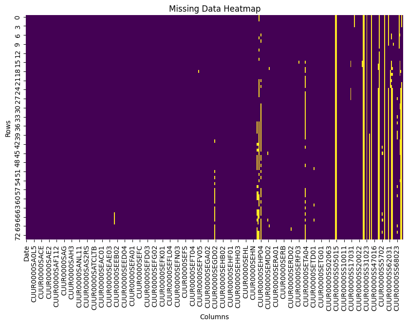

```python
# Identify any columns with missing values
missing_columns = cpi_revolns.columns[cpi_revolns.isnull().any()].tolist()
# Display the columns with missing values and their counts in a table
missing_counts = cpi_revolns[missing_columns].isnull().sum()
missing_df = pd.DataFrame({'Column': missing_columns, 'Missing Count': missing_counts})
# Display the DataFrame with missing values
display(missing_df)

# Show the distribution of the missing data
plt.figure(figsize=(10, 6))
sns.heatmap(cpi_revolns.isnull(), cbar=False, cmap='viridis')
plt.title('Missing Data Heatmap')
plt.xlabel('Columns')
plt.ylabel('Rows')
plt.show()
```

From the table and the heatmap we can see many of our features are missing data. Since we pulled all series available for CPI data we should drop these as they won't be relevant or able to be impute missing values given the quantity of gaps in the data. This should be okay as there are many feautres to still use and some top level categorical features exist in this set too.

```python
# drop and track the columns with missing values and list out the columns that were dropped
# Drop the columns with missing values
cpi_revolns_dropped = cpi_revolns.dropna(axis=1)
# Display the columns that were dropped
dropped_columns = cpi_revolns.columns[cpi_revolns.isnull().any()].tolist()
# Display the columns that were dropped
print("Columns dropped due to missing values:")
print(dropped_columns)
# Display the first few rows of the modified DataFrame
display(cpi_revolns_dropped.head())
# Display the shape of the modified DataFrame
print("Shape of the modified DataFrame after dropping columns with missing values:")
print(cpi_revolns_dropped.shape)

# Check the data types of the columns in the modified DataFrame
print("Data types of the columns in the modified DataFrame:")
print(cpi_revolns_dropped.dtypes)
```

[output not shown]

|  | Date | CUUR0000SA0E | CUUR0000SA0L1 | CUUR0000SA0L12 | CUUR0000SA0L12E | CUUR0000SA0L12E4 | CUUR0000SA0L1E | CUUR0000SA0L2 | CUUR0000SA0L5 | CUUR0000SA0LE | ... | CUUR0000SS61011 | CUUR0000SS61023 | CUUR0000SS61031 | CUUR0000SS61032 | CUUR0000SS62031 | CUUR0000SS62054 | CUUR0000SS62055 | CUUR0000SS68021 | CUUR0000SSEA011 | REVOLNS |
| --- | --- | --- | --- | --- | --- | --- | --- | --- | --- | --- | --- | --- | --- | --- | --- | --- | --- | --- | --- | --- | --- |
| 0 | 2019-01-01 | 200.563 | 250.974 | 224.129 | 230.902 | 236.57 | 260.122 | 230.765 | 240.27 | 258.855 | ... | 40.351 | 22.075 | 151.723 | 116.707 | 182.806 | 260.653 | 129.37 | 172.297 | 236.214 | 1032945.77 |
| 1 | 2019-02-01 | 202.74 | 252.077 | 225.199 | 231.788 | 237.48 | 261.114 | 231.792 | 241.335 | 259.817 | ... | 40.436 | 21.74 | 152.726 | 117.106 | 183.353 | 263.218 | 129.457 | 172.297 | 238.122 | 1014636.99 |
| 2 | 2019-03-01 | 211.724 | 253.643 | 226.909 | 232.222 | 237.836 | 261.836 | 233.29 | 242.776 | 260.505 | ... | 40.359 | 21.875 | 153.469 | 116.952 | 184.355 | 264.507 | 132.573 | 172.297 | 238.055 | 1005252.17 |
| 3 | 2019-04-01 | 222.499 | 255.194 | 228.655 | 232.38 | 238.012 | 262.332 | 234.723 | 244.134 | 260.925 | ... | 39.829 | 22.223 | 154.079 | 117.332 | 184.811 | 265.119 | 134.836 | 172.297 | 238.826 | 1013742.65 |
| 4 | 2019-05-01 | 225.773 | 255.759 | 229.061 | 232.28 | 238.051 | 262.59 | 235.131 | 244.629 | 261.203 | ... | 39.355 | 21.994 | 154.985 | 118.148 | 186.395 | 266.297 | 133.271 | 172.297 | 237.06 | 1028795.53 |

5 rows × 361 columns

```
Shape of the modified DataFrame after dropping columns with missing values:
(74, 361)
Data types of the columns in the modified DataFrame:
Date               datetime64[ns]
CUUR0000SA0E               object
CUUR0000SA0L1              object
CUUR0000SA0L12             object
CUUR0000SA0L12E            object
                        ...
CUUR0000SS62054            object
CUUR0000SS62055            object
CUUR0000SS68021            object
CUUR0000SSEA011            object
REVOLNS                   float64
Length: 361, dtype: object
```

```python
# All columns exccept the Date column should be float
# Convert all columns except the Date column to float
cpi_revolns_dropped[cpi_revolns_dropped.columns[1:]] = cpi_revolns_dropped[cpi_revolns_dropped.columns[1:]].astype(float)

# Describe the data to get a summary of the statistics
# Display the summary statistics of the modified DataFrame
cpi_revolns_dropped.dtypes
```

```
Date               datetime64[ns]
CUUR0000SA0E              float64
CUUR0000SA0L1             float64
CUUR0000SA0L12            float64
CUUR0000SA0L12E           float64
                        ...
CUUR0000SS62054           float64
CUUR0000SS62055           float64
CUUR0000SS68021           float64
CUUR0000SSEA011           float64
REVOLNS                   float64
Length: 361, dtype: object
```

We are going to create a filtered set of features based on the major expenditure categories (mec) defined by BLS. For reference, see https://www.bls.gov/cpi/additional-resources/cpi-item-aggregation.htm

the major_expenditure_categories will have both a Name and a 3-digit code. The 3-digit code follows the base_code prefix for our series features of 'CUUR0000' to create the major series names.

For this analysis we will only focus on the major categories vs analyzing the hundreds of sub categories.

```python
# Create a list of major expenditure categories that comprise of the name of the major expenditure category and the corresponding code
major_expenditure_categories = [
    ('Food_and_Beverages', 'SAF'),
    ('Housing', 'SAH'),
    ('Apparel', 'SAA'),
    ('Transportation', 'SAT'),
    ('Medical_Care', 'SAM'),
    ('Recreation', 'SAR'),
    ('Education_and_Communication', 'SAE'),
    ('Other_Goods_and_Services', 'SAG')
]

# Createe new df that only has the major expenditure categories as features along with the REVOLNS column and the Date column
# Create a new DataFrame with the Date column, REVOLNS column, and major expenditure categories
cpi_revolns_major = cpi_revolns_dropped[['Date', 'REVOLNS']].copy()
# Loop through the major expenditure categories and add them to the new DataFrame
base_code = 'CUUR0000'

for category, code in major_expenditure_categories:
    # Add the column to the new DataFrame
    cpi_revolns_major[category] = cpi_revolns_dropped[base_code + code]
# Display the first few rows of the new DataFrame
display(cpi_revolns_major.dtypes)
# Display the shape of the new DataFrame
```

```
Date                           datetime64[ns]
REVOLNS                               float64
Food_and_Beverages                    float64
Housing                               float64
Apparel                               float64
Transportation                        float64
Medical_Care                          float64
Recreation                            float64
Education_and_Communication           float64
Other_Goods_and_Services              float64
dtype: object
```

Let's analyze the data and features for any outliers that we should consider handling before analysis.

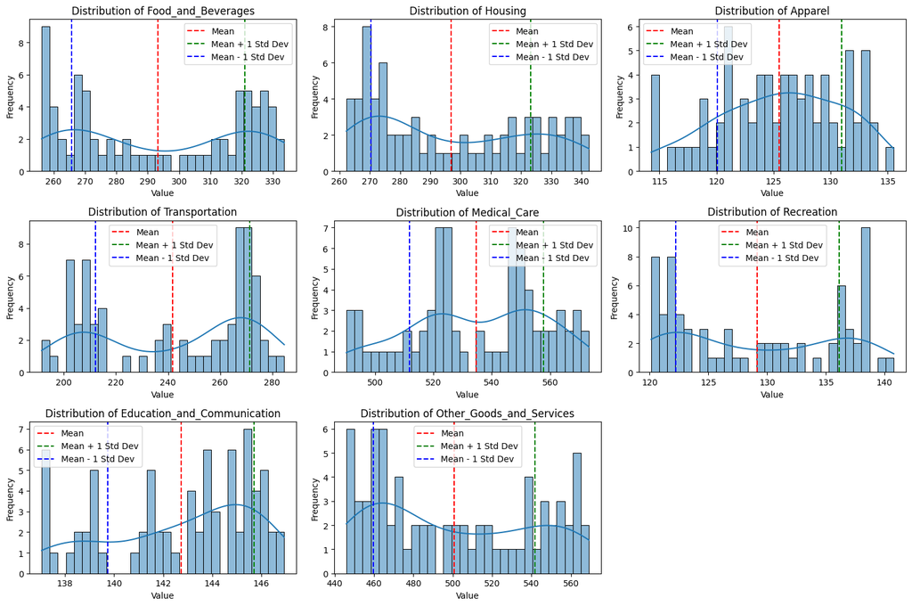

```python
# Plot the data distributions for each major expenditure category along with their standard deviations
plt.figure(figsize=(15, 10))

for i, (category, code) in enumerate(major_expenditure_categories):
    plt.subplot(3, 3, i + 1)
    sns.histplot(cpi_revolns_major[category], bins=30, kde=True)
    plt.title(f'Distribution of {category}')
    plt.xlabel('Value')
    plt.ylabel('Frequency')
    plt.axvline(cpi_revolns_major[category].mean(), color='r', linestyle='--', label='Mean')
    plt.axvline(cpi_revolns_major[category].mean() + cpi_revolns_major[category].std(), color='g', linestyle='--', label='Mean + 1 Std Dev')
    plt.axvline(cpi_revolns_major[category].mean() - cpi_revolns_major[category].std(), color='b', linestyle='--', label='Mean - 1 Std Dev')
    plt.legend()
plt.tight_layout()
plt.show()
```

Using the above output we can see that the width of the data is relatively narrow for each feature with no significant outlier.

By looking at the standard deviations on the charts we will make no further recommendations to adjust our dataset before EDA.

## Exploratory Data Analysis (EDA)

|  | REVOLNS | Food_and_Beverages | Housing | Apparel | Transportation | Medical_Care | Recreation | Education_and_Communication | Other_Goods_and_Services |
| --- | --- | --- | --- | --- | --- | --- | --- | --- | --- |
| REVOLNS | 1.000000 | 0.890658 | 0.922228 | 0.825472 | 0.793755 | 0.793083 | 0.902193 | 0.726236 | 0.916559 |
| Food_and_Beverages | 0.890658 | 1.000000 | 0.989486 | 0.783849 | 0.922655 | 0.961143 | 0.994197 | 0.934885 | 0.987895 |
| Housing | 0.922228 | 0.989486 | 1.000000 | 0.792188 | 0.893316 | 0.950682 | 0.992709 | 0.915434 | 0.998718 |
| Apparel | 0.825472 | 0.783849 | 0.792188 | 1.000000 | 0.812909 | 0.659365 | 0.803872 | 0.644523 | 0.786977 |
| Transportation | 0.793755 | 0.922655 | 0.893316 | 0.812909 | 1.000000 | 0.873421 | 0.917466 | 0.871122 | 0.890682 |
| Medical_Care | 0.793083 | 0.961143 | 0.950682 | 0.659365 | 0.873421 | 1.000000 | 0.947681 | 0.952889 | 0.951602 |
| Recreation | 0.902193 | 0.994197 | 0.992709 | 0.803872 | 0.917466 | 0.947681 | 1.000000 | 0.928813 | 0.992164 |
| Education_and_Communication | 0.726236 | 0.934885 | 0.915434 | 0.644523 | 0.871122 | 0.952889 | 0.928813 | 1.000000 | 0.919493 |
| Other_Goods_and_Services | 0.916559 | 0.987895 | 0.998718 | 0.786977 | 0.890682 | 0.951602 | 0.992164 | 0.919493 | 1.000000 |

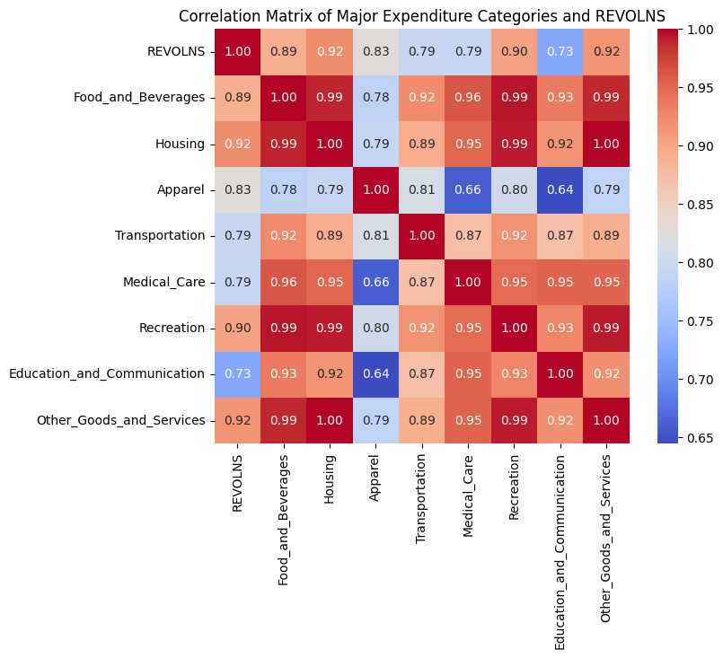

```python
# Create a correlation matrix to visualize the relationships between the major expenditure categories and REVOLNS but do not include the Date column
# Calculate the correlation matrix

eda_corr_df = cpi_revolns_major.drop(columns=['Date'])
correlation_matrix = eda_corr_df.corr()
# Display the correlation matrix
display(correlation_matrix)
# Plot the correlation matrix using a heatmap
plt.figure(figsize=(8, 6))
sns.heatmap(correlation_matrix, annot=True, cmap='coolwarm', fmt='.2f', square=True)
plt.title('Correlation Matrix of Major Expenditure Categories and REVOLNS')
plt.show()
```

**Key Observations**

**Revolving Credit (REVOLNS) Correlations:**

1. At 0.922 Housing has the highest correlation with REVOLNS which indicates this strongly drives credit usage.
2. At 0.916 Other goods and services (OGS) has a strong correlation with spending and increased credit
3. Transportation, Medical Care, and Education and Communication are all still highly correlated but have weaker correlation values so we should determine their impact on the overal REVOLNS.

**Inter-CPI Category Correlations:**

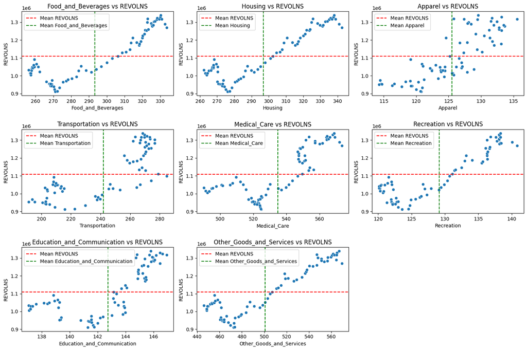

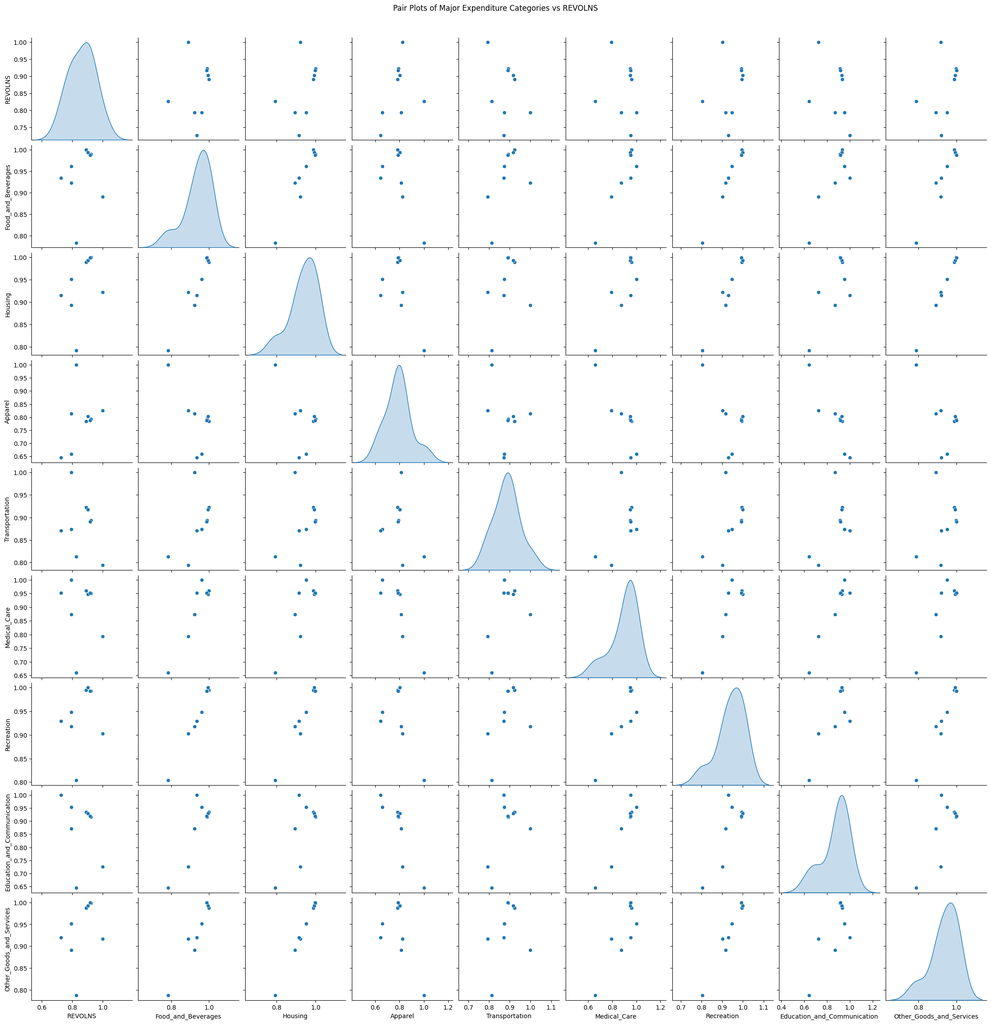

```python
# Explore relationships between REVOLNS and each major expenditure category using scatter plots
plt.figure(figsize=(15, 10))
for i, (category, code) in enumerate(major_expenditure_categories):
    plt.subplot(3, 3, i + 1)
    sns.scatterplot(x=cpi_revolns_major[category], y=cpi_revolns_major['REVOLNS'])
    plt.title(f'{category} vs REVOLNS')
    plt.xlabel(category)
    plt.ylabel('REVOLNS')
    plt.axhline(y=cpi_revolns_major['REVOLNS'].mean(), color='r', linestyle='--', label='Mean REVOLNS')
    plt.axvline(x=cpi_revolns_major[category].mean(), color='g', linestyle='--', label=f'Mean {category}')
    plt.legend()
plt.tight_layout()
plt.show()

# Explore relationships between REVOLNS and each major expenditure category using pair plots with KDE
# Create pair plots for each major expenditure category against REVOLNS
plt.figure(figsize=(15, 10))
sns.pairplot(correlation_matrix, diag_kind='kde')
plt.suptitle('Pair Plots of Major Expenditure Categories vs REVOLNS', y=1.02)
plt.show()
```

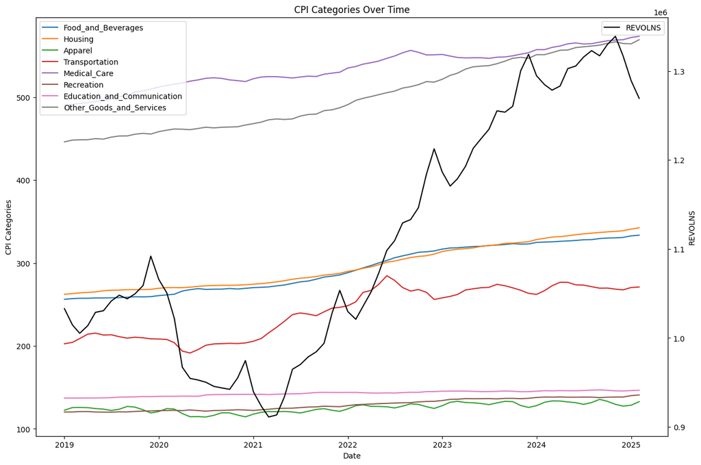

```python
# Understand if there is any seasonality in the REVOLNS data compared to the major expenditure categories
# Create a new DataFrame to set index to Date
seasonal_df = cpi_revolns_major.copy()

# Set the Date column as the index
seasonal_df.set_index('Date', inplace=True)

# plot CPI categories on the left and REVOLNS on the right
fig, ax1 = plt.subplots(figsize=(15, 10))
# Plot the major expenditure categories
for category, code in major_expenditure_categories:
    ax1.plot(seasonal_df.index, seasonal_df[category], label=category)
ax1.set_xlabel('Date')
ax1.set_ylabel('CPI Categories')
ax1.set_title('CPI Categories Over Time')
ax1.legend(loc='upper left')
# Create a second y-axis for REVOLNS
ax2 = ax1.twinx()
# Plot REVOLNS on the second y-axis
ax2.plot(seasonal_df.index, seasonal_df['REVOLNS'], color='black', label='REVOLNS')
ax2.set_ylabel('REVOLNS')
ax2.legend(loc='upper right')
plt.show()
```

In the above chart you can see the variance of REVOLNS on the right y axis while all of the CPI Categories are aligned to the left y-axis and plotted over time. It is interesting to note how limited the variability appears in the CPI category volume.

For instance, looking at Education and Communication along with Recreation there is limited growth in the CPI for these categories. Even Apparel has some seasonal volatility but the growth of the impact on CPI seems negligble over this time period.

Medical, OGS, Housing would be the top choices for primary drivers of the REVOLNS credit impact in terms of CPI factors.

### Modeling

```python
# We will attempt to predict the REVOLNS using the major expenditure categories as features with a polynomial regression model

# Define the columns to be used as features
columns = seasonal_df.columns.drop('REVOLNS')
formula = 'REVOLNS ~ ' + ' + '.join(columns)
print("Formula for the polynomial regression model:")
print(formula)
# Create a polynomial regression model
model = smf.ols(formula=formula, data=seasonal_df)

# Fit the model
results = model.fit()
# Print the summary of the model
print(results.summary())
```

```
Formula for the polynomial regression model:
REVOLNS ~ Food_and_Beverages + Housing + Apparel + Transportation + Medical_Care + Recreation + Education_and_Communication + Other_Goods_and_Services
                            OLS Regression Results
==============================================================================
Dep. Variable:                REVOLNS   R-squared:                       0.949
Model:                            OLS   Adj. R-squared:                  0.943
Method:                 Least Squares   F-statistic:                     150.9
Date:                Mon, 28 Apr 2025   Prob (F-statistic):           6.18e-39
Time:                        22:35:55   Log-Likelihood:                -869.14
No. Observations:                  74   AIC:                             1756.
Df Residuals:                      65   BIC:                             1777.
Df Model:                           8
Covariance Type:            nonrobust
===============================================================================================
                                  coef    std err          t      P>|t|      [0.025      0.975]
-----------------------------------------------------------------------------------------------
Intercept                    3.252e+06   6.04e+05      5.387      0.000    2.05e+06    4.46e+06
Food_and_Beverages           1461.0723   1691.058      0.864      0.391   -1916.203    4838.347
Housing                      1.074e+04   3336.791      3.220      0.002    4079.814    1.74e+04
Apparel                      1396.1621   1625.935      0.859      0.394   -1851.054    4643.378
Transportation                 71.7106    421.889      0.170      0.866    -770.861     914.282
Medical_Care                -2777.9266    876.607     -3.169      0.002   -4528.632   -1027.221
Recreation                  -9751.7432   7525.975     -1.296      0.200   -2.48e+04    5278.666
Education_and_Communication -2.067e+04   4978.652     -4.153      0.000   -3.06e+04   -1.07e+04
Other_Goods_and_Services     -514.5137   1994.580     -0.258      0.797   -4497.965    3468.937
==============================================================================
Omnibus:                       11.291   Durbin-Watson:                   0.401
Prob(Omnibus):                  0.004   Jarque-Bera (JB):               12.436
Skew:                           0.758   Prob(JB):                      0.00199
Kurtosis:                       4.318   Cond. No.                     1.45e+05
==============================================================================

Notes:
[1] Standard Errors assume that the covariance matrix of the errors is correctly specified.
[2] The condition number is large, 1.45e+05. This might indicate that there are
strong multicollinearity or other numerical problems.
```

After performing this initial EDA we can see there is strong multicollinearity of the data which also seems representative from when we calculated the correlation matrix.

According to some research we should calculate the variance inflation factor (VIF) for each predictor to determine the multicollinearity. We will do this next.

**note: below is the VIF analysis and in learning more about collinearity I increased the samples to be from 2019 forward vs just 2023 forward. In doing so I noticed that Housing, Medical Care, and Education and Communication have the best performing P values.

```python
# Calculate the VIF for each feature

# Create a DataFrame to hold the VIF values
vif_df = pd.DataFrame()
vif_df['Feature'] = columns
vif_df['VIF'] = [variance_inflation_factor(seasonal_df[columns].values, i) for i in range(len(columns))]
# Display the VIF values
display(vif_df)
```

|  | Feature | VIF |
| --- | --- | --- |
| 0 | Food_and_Beverages | 13242.240864 |
| 1 | Housing | 68805.206611 |
| 2 | Apparel | 2322.908446 |
| 3 | Transportation | 643.373060 |
| 4 | Medical_Care | 14161.699793 |
| 5 | Recreation | 52408.833248 |
| 6 | Education_and_Communication | 25408.456121 |
| 7 | Other_Goods_and_Services | 66937.133728 |

The VIF is extreme and likely related to the multicollinearity and small sample size in this dataset. *note: given the challenges with the size of the dataset from 2023-2025 I decided to go back and start from 2019 to acquire more observations for the sample size*

In looking at the regression output we'll focus on Housing, Other Goods and Services (OGS), and Medical Care.

VIF should be below 10.

```python
# Test regression with only Housing, Medical Care and REVOLNS
columns_updated = ['Housing', 'Medical_Care']
formula_updated = 'REVOLNS ~ ' + ' + '.join(columns_updated)
print("Updated formula for the polynomial regression model:")
print(formula_updated)
# Create a regression model
model_updated = smf.ols(formula=formula_updated, data=seasonal_df)
# Fit the model
results_updated = model_updated.fit()
# Print the summary of the model
print(results_updated.summary())
```

```
Updated formula for the polynomial regression model:
REVOLNS ~ Housing + Medical_Care
                            OLS Regression Results
==============================================================================
Dep. Variable:                REVOLNS   R-squared:                       0.923
Model:                            OLS   Adj. R-squared:                  0.921
Method:                 Least Squares   F-statistic:                     427.1
Date:                Mon, 28 Apr 2025   Prob (F-statistic):           2.62e-40
Time:                        22:35:55   Log-Likelihood:                -884.19
No. Observations:                  74   AIC:                             1774.
Df Residuals:                      71   BIC:                             1781.
Df Model:                           2
Covariance Type:            nonrobust
================================================================================
                   coef    std err          t      P>|t|      [0.025      0.975]
--------------------------------------------------------------------------------
Intercept     1.181e+06   1.88e+05      6.286      0.000    8.06e+05    1.55e+06
Housing       9021.9515    546.771     16.500      0.000    7931.720    1.01e+04
Medical_Care -5142.6496    626.813     -8.204      0.000   -6392.480   -3892.819
==============================================================================
Omnibus:                        3.859   Durbin-Watson:                   0.247
Prob(Omnibus):                  0.145   Jarque-Bera (JB):                3.257
Skew:                           0.507   Prob(JB):                        0.196
Kurtosis:                       3.174   Cond. No.                     2.59e+04
==============================================================================

Notes:
[1] Standard Errors assume that the covariance matrix of the errors is correctly specified.
[2] The condition number is large, 2.59e+04. This might indicate that there are
strong multicollinearity or other numerical problems.
```

The above output shows the coef for Medical having such a severe relationship with Housing that we should remove it. We'll try with apparel instead.

```python
# Test regression with only Housing, Medical Care and REVOLNS
columns_updated = ['Housing', 'Apparel']
formula_updated = 'REVOLNS ~ ' + ' + '.join(columns_updated)
print("Updated formula for the polynomial regression model:")
print(formula_updated)
# Create a regression model
model_updated = smf.ols(formula=formula_updated, data=seasonal_df)
# Fit the model
results_updated = model_updated.fit()
# Print the summary of the model
print(results_updated.summary())
```

```
Updated formula for the polynomial regression model:
REVOLNS ~ Housing + Apparel
                            OLS Regression Results
==============================================================================
Dep. Variable:                REVOLNS   R-squared:                       0.875
Model:                            OLS   Adj. R-squared:                  0.871
Method:                 Least Squares   F-statistic:                     247.8
Date:                Mon, 28 Apr 2025   Prob (F-statistic):           9.54e-33
Time:                        22:35:55   Log-Likelihood:                -902.34
No. Observations:                  74   AIC:                             1811.
Df Residuals:                      71   BIC:                             1818.
Df Model:                           2
Covariance Type:            nonrobust
==============================================================================
                 coef    std err          t      P>|t|      [0.025      0.975]
------------------------------------------------------------------------------
Intercept  -7.947e+05   1.48e+05     -5.384      0.000   -1.09e+06      -5e+05
Housing     3716.0511    355.114     10.464      0.000    3007.973    4424.129
Apparel     6376.4451   1722.845      3.701      0.000    2941.190    9811.700
==============================================================================
Omnibus:                        0.620   Durbin-Watson:                   0.350
Prob(Omnibus):                  0.734   Jarque-Bera (JB):                0.756
Skew:                           0.169   Prob(JB):                        0.685
Kurtosis:                       2.638   Cond. No.                     8.41e+03
==============================================================================

Notes:
[1] Standard Errors assume that the covariance matrix of the errors is correctly specified.
[2] The condition number is large, 8.41e+03. This might indicate that there are
strong multicollinearity or other numerical problems.
```

```python
# RMSE of the model
rmse = np.sqrt(mean_squared_error(seasonal_df['REVOLNS'], results_updated.fittedvalues))
print("RMSE of the model:")
print(rmse)
```

```
RMSE of the model:
47800.65666090854
```

Both coefs are positive and the p values small. This will be the most optimal model that we can get even with the high degree of multicollinearity that exists amongst Housing, Medical, etc.

### ML Modeling

In the below section we will explore trying Random Forest and Gradient Boosting models to determine impact of CPI categories on the overall REVOLNS.

Random Forest will help address potential challenges with the multicollinearity. As I read up on Random Forest I was learning that we need to handle time-series data slightly differently to handle the autocorrelation. This will be done by establishing new lagging features for each of our major category features of CPI.

Creating the lagging features for:

- 1 period lag
- 2 period lag
- 3 period lag

```python
# Create three new features for each major expenditure category based on one month, two months and three months lagged values
# Create new dataframe to hold the lagged features and the previous df cpi_revolns_major
ml_df = cpi_revolns_major.copy()

# Create lagged features for each major expenditure category

# Create 1-month lagged features
for category, code in major_expenditure_categories:
    ml_df[f'{category}_1m'] = ml_df[category].shift(1)

# Create 2-month lagged features
for category, code in major_expenditure_categories:
    ml_df[f'{category}_2m'] = ml_df[category].shift(2)

# Create 3-month lagged features
for category, code in major_expenditure_categories:
    ml_df[f'{category}_3m'] = ml_df[category].shift(3)

# Drop the first three rows with NaN values
ml_df = ml_df.dropna()

# Display the first few rows of the modified DataFrame with a category and a lagged feature
display(ml_df[['Date', 'Housing', 'Housing_1m', 'Housing_2m', 'Housing_3m']].head())
```

|  | Date | Housing | Housing_1m | Housing_2m | Housing_3m |
| --- | --- | --- | --- | --- | --- |
| 3 | 2019-04-01 | 264.452 | 263.886 | 263.057 | 262.284 |
| 4 | 2019-05-01 | 265.137 | 264.452 | 263.886 | 263.057 |
| 5 | 2019-06-01 | 266.461 | 265.137 | 264.452 | 263.886 |
| 6 | 2019-07-01 | 267.101 | 266.461 | 265.137 | 264.452 |
| 7 | 2019-08-01 | 267.263 | 267.101 | 266.461 | 265.137 |

```python
# Set date column as index
ml_df.set_index('Date', inplace=True)
display(ml_df.columns)
```

```
Index(['REVOLNS', 'Food_and_Beverages', 'Housing', 'Apparel', 'Transportation',
       'Medical_Care', 'Recreation', 'Education_and_Communication',
       'Other_Goods_and_Services', 'Food_and_Beverages_1m', 'Housing_1m',
       'Apparel_1m', 'Transportation_1m', 'Medical_Care_1m', 'Recreation_1m',
       'Education_and_Communication_1m', 'Other_Goods_and_Services_1m',
       'Food_and_Beverages_2m', 'Housing_2m', 'Apparel_2m',
       'Transportation_2m', 'Medical_Care_2m', 'Recreation_2m',
       'Education_and_Communication_2m', 'Other_Goods_and_Services_2m',
       'Food_and_Beverages_3m', 'Housing_3m', 'Apparel_3m',
       'Transportation_3m', 'Medical_Care_3m', 'Recreation_3m',
       'Education_and_Communication_3m', 'Other_Goods_and_Services_3m'],
      dtype='object')
```

We've successfully created three new features with a respective 1-month, 2-month, and 3-month lag of data and subsequently dropped the NA rows so our dataset now starts in April 2019.

We will now work on creating the ML model for the Random Forest

```python
# Create the test and train datasets
X_train, X_test, y_train, y_test = train_test_split(ml_df.drop(columns=['REVOLNS']), ml_df['REVOLNS'], test_size=12, shuffle=False)
print("Created the test and train datasets")
```

```
Created the test and train datasets
```

```
Random Forest RMSE: 23420.75
Random Forest R-squared: -0.26
```

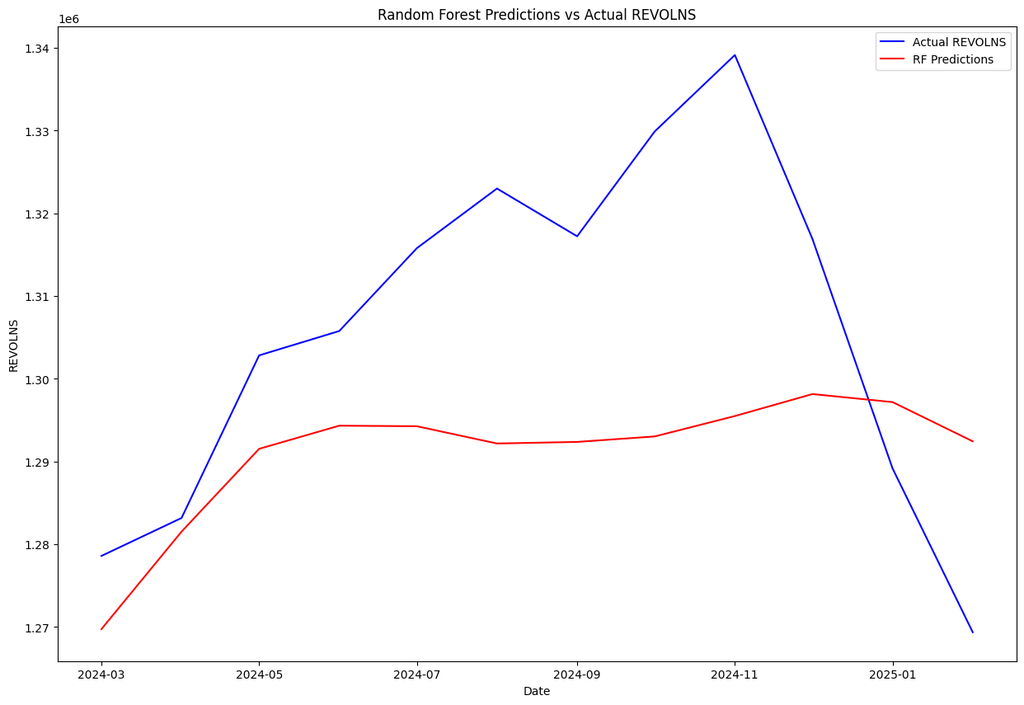

```python
# Build the RF Model
rf_model = RandomForestRegressor(n_estimators=100, max_depth=10, min_samples_split=2, random_state=42)

# Fit the model
rf_model.fit(X_train, y_train)

# Make predictions
rf_predictions = rf_model.predict(X_test)

# Calculate the RMSE
rf_rmse = np.sqrt(np.mean((rf_predictions - y_test) ** 2))
print(f"Random Forest RMSE: {rf_rmse:.2f}")
# Calculate the R-squared value
rf_r2 = rf_model.score(X_test, y_test)
print(f"Random Forest R-squared: {rf_r2:.2f}")
# Plot the predictions vs actual values
plt.figure(figsize=(15, 10))
plt.plot(y_test.index, y_test, label='Actual REVOLNS', color='blue')
plt.plot(y_test.index, rf_predictions, label='RF Predictions', color='red')
plt.title('Random Forest Predictions vs Actual REVOLNS')
plt.xlabel('Date')
plt.ylabel('REVOLNS')
plt.legend()
plt.show()
```

Now that we have our RF Regressor working with a starting point of view. Let's focus on tuning the hyperparameters. We will look at tuning the below params and implementing search (will test GridSearch and RandomizedSearch if we use a lot of Hyperparams):

- n_estimators
- max_depth
- min_samples_split

```
Best parameters: {'n_estimators': 50, 'min_samples_split': 2, 'min_samples_leaf': 1, 'max_leaf_nodes': 20, 'max_features': 'log2', 'max_depth': 20, 'ccp_alpha': 0.0, 'bootstrap': False}
Best Random Forest RMSE after tuning: 58494.59
Random Forest R-squared after tuning: -0.14
```

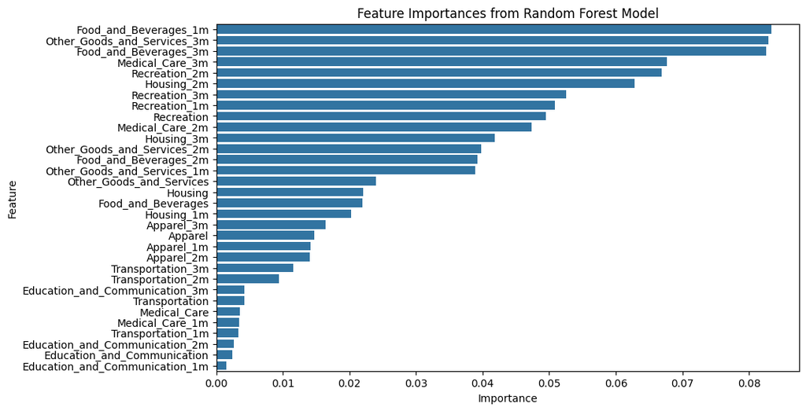

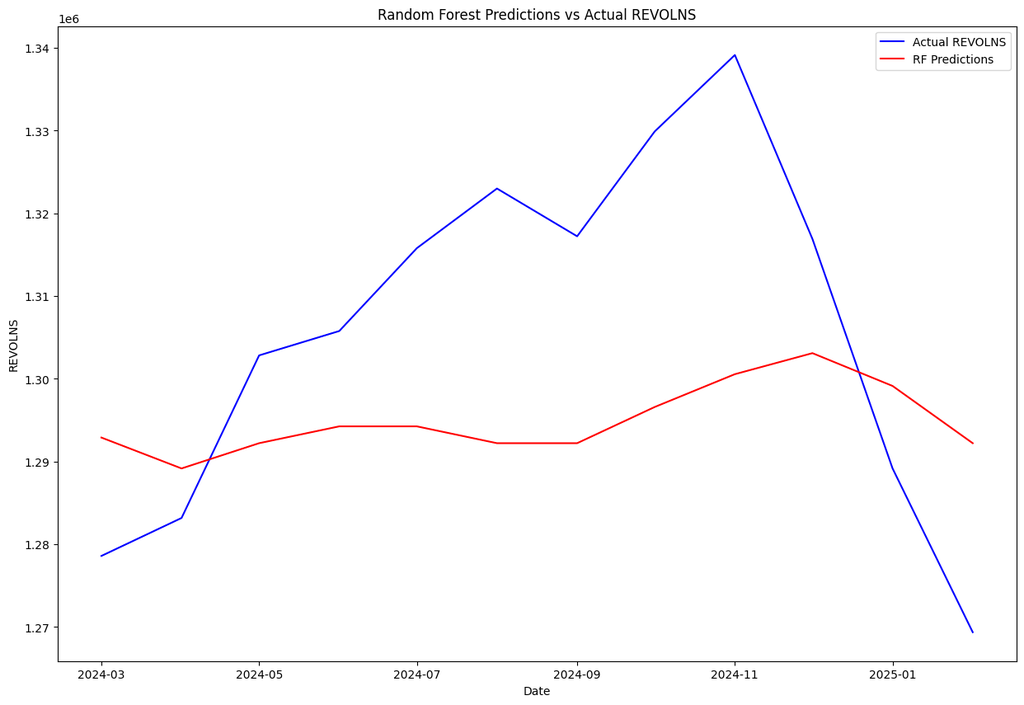

```python
# Set up the RF model for hyperparameter tuning
rf_model_tune = RandomForestRegressor(random_state=42)
# Define the parameter grid for hyperparameter tuning

param_dist = {
    'n_estimators': [50, 100, 200, 300],
    'max_depth': [5, 10, 20, None],
    'min_samples_split': [2, 5, 10],
    'min_samples_leaf': [1, 2, 5, 10],
    'max_features': ['sqrt', 'log2', None, 0.33, 0.5],
    'max_leaf_nodes': [None, 10, 20, 50],
    'bootstrap': [True, False],
    'ccp_alpha': [0.0, 0.001, 0.01, 0.1]
}


tscv = TimeSeriesSplit(n_splits=5)

random_search = RandomizedSearchCV(
    rf_model_tune,
    param_distributions=param_dist,
    n_iter=50,  # Number of parameter combinations to try
    cv=tscv,
    scoring='neg_mean_squared_error',
    n_jobs=-1,
    random_state=42
)

# Fit the model
random_search.fit(X_train, y_train)

rf_tune_rmse = np.sqrt(-random_search.best_score_)
print(f"Best parameters: {random_search.best_params_}")
print(f"Best Random Forest RMSE after tuning: {rf_tune_rmse:.2f}")
# Calculate the R-squared value
rf_tune_r2 = r2_score(y_test, random_search.predict(X_test))
print(f"Random Forest R-squared after tuning: {rf_tune_r2:.2f}")


best_rf_model = random_search.best_estimator_

# Feature importance
importances = best_rf_model.feature_importances_
# Create a DataFrame for feature importances
importances_df = pd.DataFrame({'Feature': X_train.columns, 'Importance': importances})
# Sort the DataFrame by importance
importances_df = importances_df.sort_values(by='Importance', ascending=False)
# Display the feature importances
plt.figure(figsize=(10, 6))
sns.barplot(x='Importance', y='Feature', data=importances_df)
plt.title('Feature Importances from Random Forest Model')
plt.xlabel('Importance')
plt.ylabel('Feature')
plt.show()

rf_predictions_tune = best_rf_model.predict(X_test)

# Plot the predictions vs actual values
plt.figure(figsize=(15, 10))
plt.plot(y_test.index, y_test, label='Actual REVOLNS', color='blue')
plt.plot(y_test.index, rf_predictions_tune, label='RF Predictions', color='red')
plt.title('Random Forest Predictions vs Actual REVOLNS')
plt.xlabel('Date')
plt.ylabel('REVOLNS')
plt.legend()
plt.show()
```

The result with hyperparameter tuning shows that we're likely missing a lot of other features/factors that would help predict the REVOLNS value. We will attempt Gradient Boosting to see if that yields any different result.

**Gradient Boosting with XGBoost & Hyperparameter Tuning**

```
XGBoost RMSE: 18587.93
XGBoost R-squared: 0.20
```

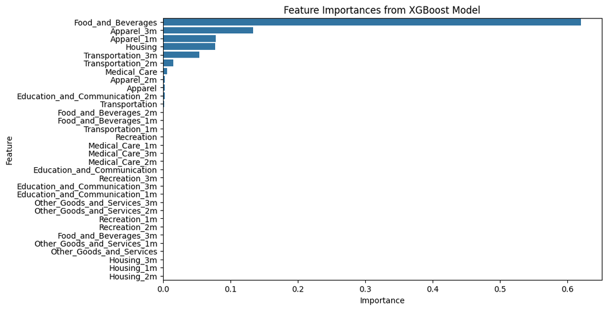

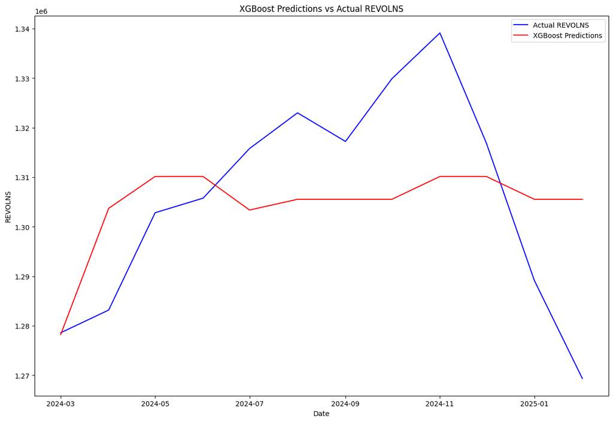

```python
# Gradient Boosting with XGBoost

# Create the XGBoost model
xgb_model = XGBRegressor(random_state=42)

# Fit the model
xgb_model.fit(X_train, y_train)

# Make predictions
xgb_predictions = xgb_model.predict(X_test)
# Calculate the RMSE
xgb_rmse = np.sqrt(np.mean((xgb_predictions - y_test) ** 2))
print(f"XGBoost RMSE: {xgb_rmse:.2f}")
# Calculate the R-squared value
xgb_r2 = xgb_model.score(X_test, y_test)
print(f"XGBoost R-squared: {xgb_r2:.2f}")

# Show the feature importances
importances_xgbm = xgb_model.feature_importances_
# Create a DataFrame for feature importances
importances_xgbm_df = pd.DataFrame({'Feature': X_train.columns, 'Importance': importances_xgbm})
# Sort the DataFrame by importance
importances_xgbm_df = importances_xgbm_df.sort_values(by='Importance', ascending=False)
# Display the feature importances
plt.figure(figsize=(10, 6))
sns.barplot(x='Importance', y='Feature', data=importances_xgbm_df)
plt.title('Feature Importances from XGBoost Model')
plt.xlabel('Importance')
plt.ylabel('Feature')
plt.show()

# Plot the predictions vs actual values
plt.figure(figsize=(15, 10))
plt.plot(y_test.index, y_test, label='Actual REVOLNS', color='blue')
plt.plot(y_test.index, xgb_predictions, label='XGBoost Predictions', color='red')
plt.title('XGBoost Predictions vs Actual REVOLNS')
plt.xlabel('Date')
plt.ylabel('REVOLNS')
plt.legend()
plt.show()

#
```

```
Fitting 3 folds for each of 50 candidates, totalling 150 fits
Best Hyperparameters: {'subsample': 0.8, 'reg_lambda': 5.0, 'reg_alpha': 0.01, 'n_estimators': 150, 'max_depth': 4, 'learning_rate': 0.2, 'gamma': 0.1, 'colsample_bytree': 1.0}
Best Cross-Validation RMSE: 66802.99 million ($)
XGBoost Test RMSE: 18399.73 million ($)
XGBoost Test R-squared: 0.22
Mean REVOLNS: 1073224.44 million ($)
Relative RMSE: 1.71%
XGBoost Feature Importances:
                        Feature  Importance
0            Food_and_Beverages    0.692793
27            Transportation_3m    0.058521
26                   Apparel_3m    0.050229
6   Education_and_Communication    0.042137
18                   Apparel_2m    0.036840
1                       Housing    0.027572
2                       Apparel    0.024061
15  Other_Goods_and_Services_1m    0.017908
10                   Apparel_1m    0.008122
4                  Medical_Care    0.007597
Feature        object
Importance    float32
dtype: object
```

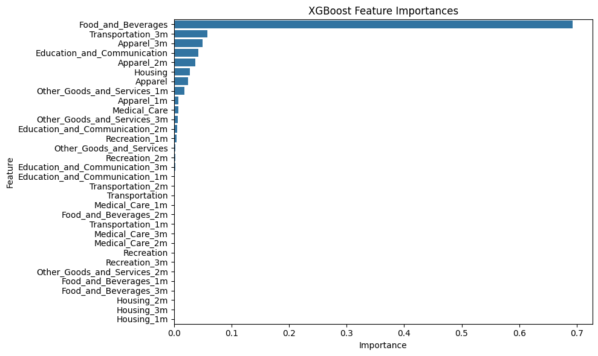

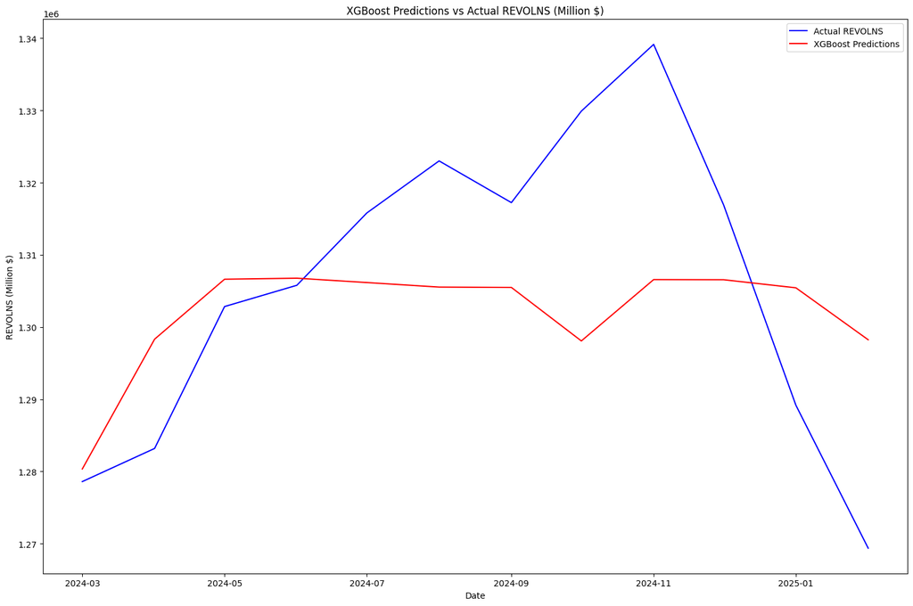

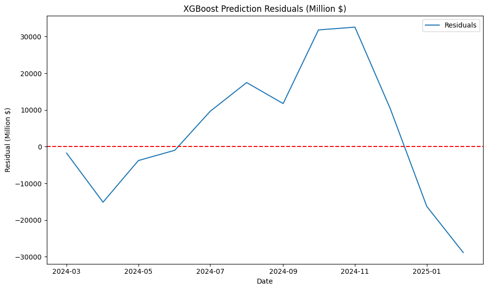

```python
# Gradient Boosting Model with XGBoost and Random Search Hyperparameter tuning

# Set up the XGBoost model
xgb_model_tune = XGBRegressor(random_state=42)

param_dist_xgb = {
    'n_estimators': [50, 100, 150, 200],
    'max_depth': [3, 4, 5, 6 ],
    'learning_rate': [0.01, 0.05, 0.1, 0.2],
    'subsample': [0.6, 0.8, 1.0],
    'colsample_bytree': [0.6, 0.8, 1.0],
    'gamma': [0, 0.1, 0.2],
    'reg_alpha': [0, 0.01, 0.1, 0.5],
    'reg_lambda': [0.5, 1.0, 2.0, 5.0]
}

# Time-series cross-validation
tscv = TimeSeriesSplit(n_splits=3)

# Randomized search
random_search_xgb = RandomizedSearchCV(
    estimator=xgb_model_tune,
    param_distributions=param_dist_xgb,
    n_iter=50,  # Number of parameter combinations to try
    cv=tscv,
    scoring='neg_mean_squared_error',
    n_jobs=-1,
    random_state=42,
    verbose=1
)

# Fit the model
random_search_xgb.fit(X_train, y_train)

# Extract best model and parameters
best_xgb_model = random_search_xgb.best_estimator_
print("Best Hyperparameters:", random_search_xgb.best_params_)
print(f"Best Cross-Validation RMSE: {np.sqrt(-random_search_xgb.best_score_):.2f} million ($)")


# Test set evaluation
xgb_predictions_tune = best_xgb_model.predict(X_test)
xgb_test_rmse = np.sqrt(mean_squared_error(y_test, xgb_predictions_tune))
xgb_test_r2 = r2_score(y_test, xgb_predictions_tune)
print(f"XGBoost Test RMSE: {xgb_test_rmse:.2f} million ($)")
print(f"XGBoost Test R-squared: {xgb_test_r2:.2f}")

# Relative RMSE
mean_revolns = y_train.mean()
relative_rmse = (xgb_test_rmse / mean_revolns) * 100
print(f"Mean REVOLNS: {mean_revolns:.2f} million ($)")
print(f"Relative RMSE: {relative_rmse:.2f}%")

# Feature importance
importances_xgb = pd.DataFrame({'Feature': X_train.columns, 'Importance': best_xgb_model.feature_importances_})
importances_xgb = importances_xgb.sort_values(by='Importance', ascending=False)
print("XGBoost Feature Importances:")
print(importances_xgb.head(10))

print(importances_xgb.dtypes)
# Plot feature importances
plt.figure(figsize=(10, 6))
sns.barplot(x='Importance', y='Feature', data=importances_xgb)
plt.title('XGBoost Feature Importances')
plt.xlabel('Importance')
plt.ylabel('Feature')
plt.tight_layout()
plt.show()

# Plot predictions vs actual
plt.figure(figsize=(15, 10))
plt.plot(y_test.index, y_test, label='Actual REVOLNS', color='blue')
plt.plot(y_test.index, xgb_predictions_tune, label='XGBoost Predictions', color='red')
plt.title('XGBoost Predictions vs Actual REVOLNS (Million $)')
plt.xlabel('Date')
plt.ylabel('REVOLNS (Million $)')
plt.legend()
plt.tight_layout()
plt.show()

# Residual plot
residuals = y_test - xgb_predictions_tune
plt.figure(figsize=(10, 6))
plt.plot(y_test.index, residuals, label='Residuals')
plt.axhline(0, color='red', linestyle='--')
plt.title('XGBoost Prediction Residuals (Million $)')
plt.xlabel('Date')
plt.ylabel('Residual (Million $)')
plt.legend()
plt.tight_layout()
plt.show()
```

```python
mean_revolns = y_train.mean()
relative_rmse_xg = (xgb_rmse / mean_revolns) * 100
relative_rmse_rf = (rf_tune_rmse / mean_revolns) * 100
relative_rmse_xgtune = (xgb_test_rmse / mean_revolns) * 100
print(f"Relative RMSE for XGBoost: {relative_rmse_xg:.2f}%")
print(f"Relative RMSE for Random Forest Tuned: {relative_rmse_rf:.2f}%")
print(f"Relative RMSE for XGBoost Tuned: {relative_rmse_xgtune:.2f}%")
print(f"Mean REVOLNS: {mean_revolns:.2f} million")
```

```
Relative RMSE for XGBoost: 1.73%
Relative RMSE for Random Forest Tuned: 5.45%
Relative RMSE for XGBoost Tuned: 1.71%
Mean REVOLNS: 1073224.44 million
```

Let's review our model performances:

**Random Forest** Random Forest RMSE: 23420.75 Random Forest R-squared: -0.26

**Random Forest with Hyperparameter Tuning** Best Random Forest RMSE after tuning: 58494.59 Random Forest R-squared after tuning: -0.14

**XGBoost** XGBoost RMSE: 18587.93 XGBoost R-squared: 0.20

**XGBoost with Hyperparameter Tuning** XGBoost Test RMSE: 18399.73 XGBoost Test R-squared: 0.22

**Relative RMSE for select models** Relative RMSE for XGBoost: 1.73% Relative RMSE for Random Forest Tuned: 5.45% Relative RMSE for XGBoost Tuned: 1.71% Mean REVOLNS: 1073224.44 million

Tuning XGBoost was able to create the lowest RMSE and best R-squared for the ML models tested. It is a good indicator that the relative RMSE values are so low in comparison to the REVOLNS data. This shows that the models predictions are decently accurate but with the R-squared value so low we likely are not accounting for all significant factors that impact the REVOLNS. The result shows that CPI could equate for about 20% of the overall impact to the REVOLNS.

## Recap and summary of approach

**GOAL: This notebook focused on understanding how the Consumer Price Index across Major Expenditure Categories contributes to the Revolving Consumer Credit amount**

**To seek this goal we peformed:**

1. Data Collection, Preparation, and Cleaning
2. Exploratory Data Analysis (EDA)
3. Initial Modeling and Multicollinearity Assessment
4. Advanced Machine Learning (ML) Model Development

### Data Collection and Preparation

- Data Acquisition: Obtained Consumer Price Index (CPI) data from the US Bureau of Labor Statistics and revolving credit (REVOLNS) data from FRED.
- Data Cleaning: Handled formatting issues, removed irrelevant rows, standardized date formats, and aligned timeframes between datasets.
- Feature Selection: Focused on major expenditure categories defined by BLS rather than analyzing hundreds of sub-categories.
- Missing Data Management: Identified and dropped columns with missing values after visualizing the extent of missingness.

### Exploratory Data Analysis (EDA)

- Distribution Analysis: Examined distributions of each major expenditure category and checked for outliers.
- Correlation Analysis: Created correlation matrices to understand relationships between CPI categories and revolving credit.
- Visual Exploration: Generated scatter plots, pair plots, and time series visualizations to identify patterns and relationships.
- Seasonality Assessment: Evaluated potential seasonality in both CPI categories and revolving credit over time.

### Initial Modeling Approach

- Linear Regression: Started with a simple multiple linear regression model using all major CPI categories.
- Multicollinearity Assessment: Calculated Variance Inflation Factors (VIFs) to quantify the extreme multicollinearity.
- Model Refinement: Iteratively simplified the model by reducing features, ultimately focusing on Housing and Apparel as predictors.

### Advanced Machine Learning Approach

- Feature Engineering:

Created temporal context by generating 1-month, 2-month, and 3-month lagged features for each CPI category. Expanded the dataset timeframe to increase observations (starting from 2019 instead of 2023).

- Time Series Handling:

Implemented proper time-based train-test splitting to maintain temporal integrity. Used TimeSeriesSplit for cross-validation during hyperparameter tuning.

- Model Development:
  - Random Forest Regression:
    - Implemented baseline model with default parameters
    - Conducted extensive hyperparameter tuning using RandomizedSearchCV
    - Analyzed feature importance rankings
  - XGBoost Regression:
    - Implemented baseline model
    - Performed hyperparameter optimization across multiple parameters
    - Extracted and analyzed feature importance patterns
- Model Evaluation:
  - Calculated multiple performance metrics: RMSE, R², and relative RMSE
  - Visualized actual vs. predicted values
  - Analyzed residuals to assess model fit
  - Compared performance across different algorithms and configurations

## Findings and conclusion

### Suggested improvements

1. Explore additional datasets to enrich CPI with other factors for a complete view of what impacts the Consumer Revolving Credit
2. Address Multicollinearity: there might be ways to expand the dataset or use different analysis to manage the multicollinearity that was identified during the EDA and initial analysis
3. Lagging features for 1, 2, and 3 months respectively were added to the dataset and that helped with the ML model performance as these features were impactful in determining the best results. With a larger observational dataset we could begin looking at 6 and 12 month lagging impact as well. This would be a good next step if not enriching the CPI data with any further data sources.
4. Explore additional derivative measures to identify movement period/period that could support insights around rate of change of the given CPI categories.

### Considerations for the future

1. Prioritize additional data such as consumer credit rates, unemployment rate, consumer confidence, retail sales, and disposible income.
2. Generate different models that handle time-series data more effectively than those used in this analysis. Light research online suggests that there are more appropriate time-series modeling techniques to account for unobserved factors.
3. Consider other sub-categories within the major expenditure categories of the CPI data